# BT1101 Final Cheatsheet

Muhd Mursyid

4/25/2022

## Libraries

```r
library("tidyverse")
library("rpivotTable")
library("knitr")
library("dplyr") #need to call the library before you use the package
library("tidyr")
library("psych")
library("RColorBrewer")
library("rcompanion")
library("rstatix")
library("Rmisc")
library(factoextra) # for fviz_cluster()
library(wooldridge)
library(car)
library(lpSolve)

library(readxl)
Ecommerceshipping <- read_excel("Ecommerceshipping.xlsx")
d1 <- read.csv("CardioGoodFitness.csv")
recid = read.csv(file = 'recid.csv', header= TRUE)
```

## Data Visualisation

### Pie Chart

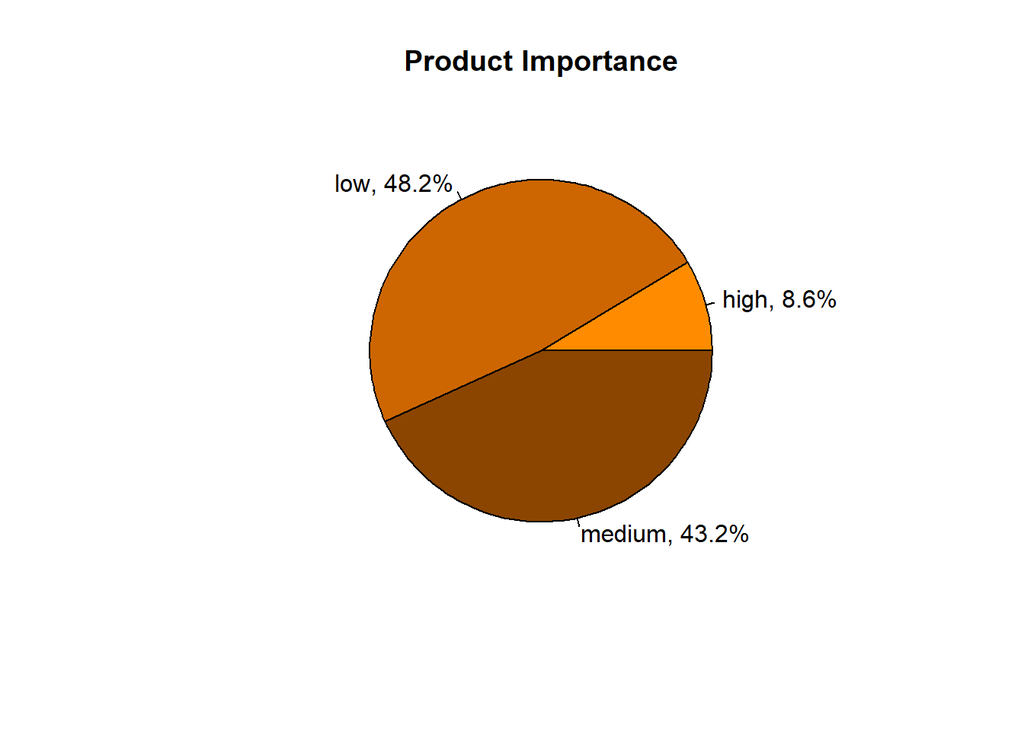

```r
# percentage label
ProductImpt_Freq <- Ecommerceshipping %>% count('Product_importance')
pie.percent <- 100 * round(ProductImpt_Freq$freq/sum(ProductImpt_Freq$freq), 3)
label <- paste(ProductImpt_Freq$Product_importance,
               ", ",
               pie.percent,
               "%",
               sep = "")
#pie chart
pie(ProductImpt_Freq$freq,
     labels = label,
     col = c("darkorange", "darkorange3", "darkorange4"),
     main = "Product Importance")
```

### Histogram

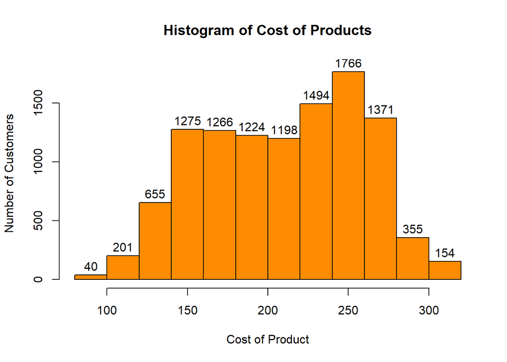

```r
#histogram
cost.hist <- hist(Ecommerceshipping$Cost_of_the_Product,
                  main = "Histogram of Cost of Products",
                  xlab = "Cost of Product",
                  ylab = "Number of Customers",
                  col = "darkorange",
                  ylim = c(0, 1800),
                  labels = TRUE)
```

```r
#generating a table from histogram
CostProduct <- cut(Ecommerceshipping$Cost_of_the_Product, cost.hist$breaks)
CostProduct.table <- table(CostProduct)
kable(CostProduct.table, caption = "Frequency distribution by Cost of Product")
```

Frequency distribution by Cost of Product

| CostProduct | Freq |
| --- | --- |
| (80,100] | 40 |
| (100,120] | 201 |
| (120,140] | 655 |
| (140,160] | 1275 |
| (160,180] | 1266 |
| (180,200] | 1224 |
| (200,220] | 1198 |
| (220,240] | 1494 |
| (240,260] | 1766 |
| (260,280] | 1371 |
| (280,300] | 355 |
| (300,320] | 154 |

### Bar Chart

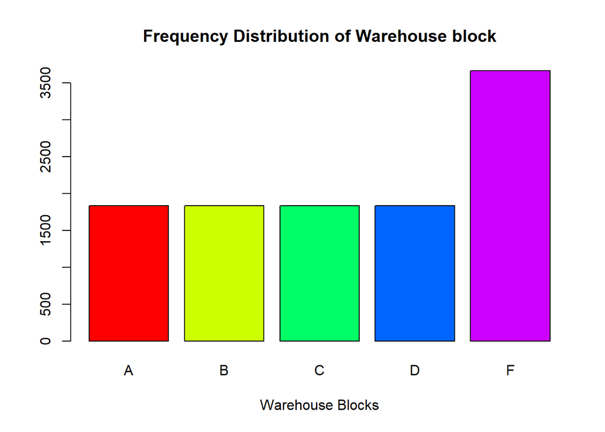

```r
WarehouseBlk_Freq <- Ecommerceshipping %>% count('Warehouse_block')
df2 <- Ecommerceshipping %>% group_by(Warehouse_block, Reached.on.Time_Y.N) %>% tally()
WarehouseBlkTimely_Freq <- spread(df2, Warehouse_block, n)
#normal bar chart
barplot(WarehouseBlk_Freq$freq,
        names.arg = WarehouseBlk_Freq$Warehouse_block,
        col = rainbow(5),
        main = "Frequency Distribution of Warehouse block",
        xlab = "Warehouse Blocks",)
```

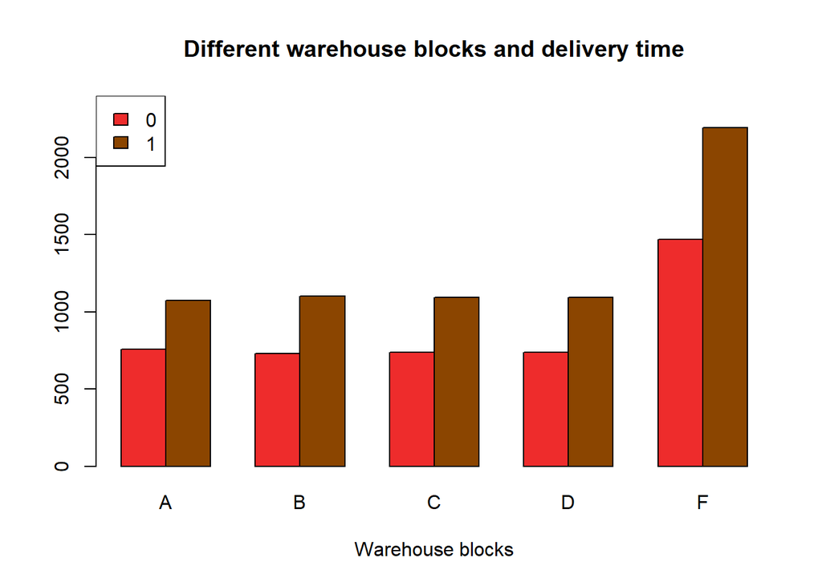

```r
#clustered bar chart
#extract and convert to matrix
df2 <- Ecommerceshipping %>% group_by(Warehouse_block, Reached.on.Time_Y.N) %>% tally()
WarehouseBlkTimely_Freq <- spread(df2, Warehouse_block, n)
matrix.WTtable <- as.matrix(WarehouseBlkTimely_Freq[,c(2:6)])

barplot(matrix.WTtable,
        main = "Different warehouse blocks and delivery time",
        col = c("firebrick2", "darkorange4"),
        ylim = c(0, 2400),
        xlab = "Warehouse blocks",
        beside = TRUE)

legend("topleft",
       fill = c("firebrick2", "darkorange4"),
       legend = WarehouseBlkTimely_Freq$Reached.on.Time_Y.N)
```

## Statistical Measures and Probability

### Pareto Analysis

```r
#Extract relevant data, x
CP <- Ecommerceshipping %>%
  select(Cost_of_the_Product) %>%
  arrange(desc(Cost_of_the_Product))

#compute percentage of x over total x
CP$Percentage <- CP$Cost_of_the_Product / sum(CP$Cost_of_the_Product)

#compute cumulative percentage for x
CP$Cum <- cumsum(CP$Percentage)

#compute cumulative percentage of customers/clients, n (basically number of data entry)
CP$Cum.cust <- as.numeric(rownames(Ecommerceshipping))/nrow(Ecommerceshipping)

#number of n contributing to at least 80% of x
which(CP$Cum > 0.8)[1]
```

```
## [1] 7898
```

```r
#percentage of total x that contributes to 80%
(which(CP$Cum > 0.8)[1])/nrow(Ecommerceshipping)
```

```
## [1] 0.7180653
```

### Outlier Analysis

Finding outliers with empirical rule - ONLY FOR NORMALLY DISTRIBUTED

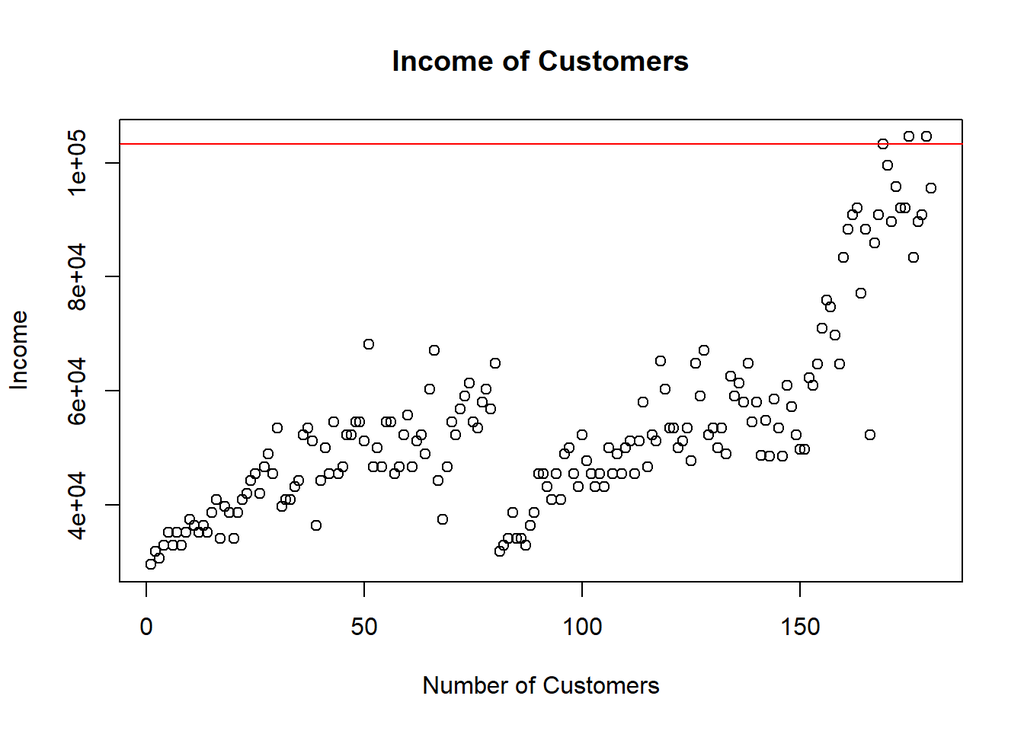

```r
plot(d1$Income, main = "Income of Customers", xlab = "Number of Customers", ylab = "Income")
LL <- mean(d1$Income) - 3 * (sd(d1$Income))
UL <- mean(d1$Income) + 3 * (sd(d1$Income))
abline(h = UL, col = "red")
abline(h = LL, col = "blue")
```

Finding outliers with box plots

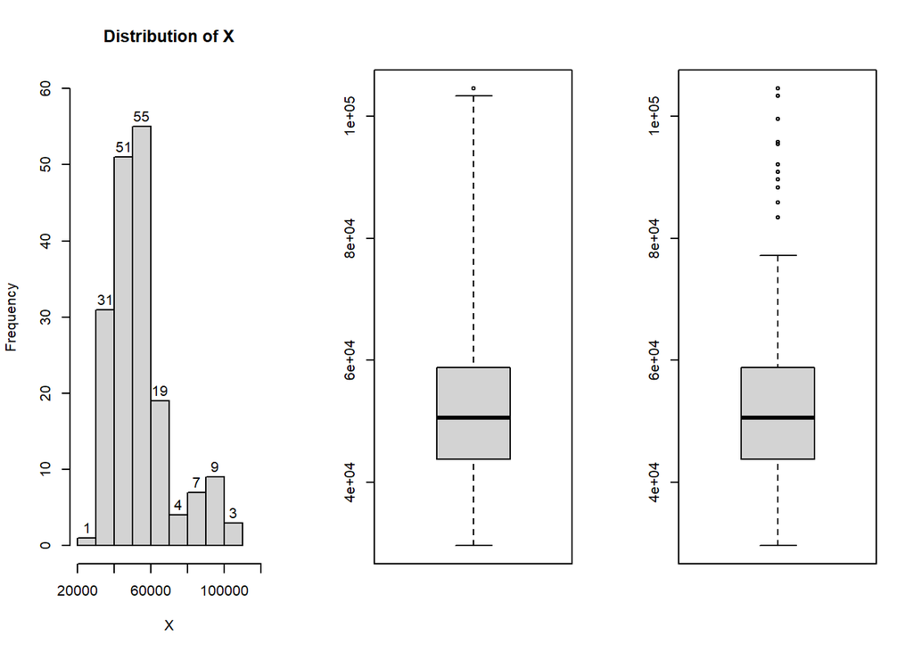

```r
#plot X as well as box plots of X with range 3 for extreme outliers and 1.5 for mild outliers
par(mfrow=c(1,3)) #this function makes plots below be displayed together
hist(d1$Income,
     labels = TRUE,
     xlim = c(20000,120000),
     ylim = c(0,60),
     main = "Distribution of X",
     xlab = "X")
boxplot(d1$Income, range = 3)
boxplot(d1$Income, range = 1.5)
```

### Computing probabilites

Probability is computed exactly like in any basic Math/Stat question. Find possible number of occurence and divide by total. In R, use nrow function to get number of rows in the tables that is already filtered for the question.

```r
df195 <- d1 %>% filter(Product == "TM195")
df62k <- df195 %>% filter(Income > 62000)
nrow(df62k)/nrow(df195)
```

```
## [1] 0.0375
```

```r
df.male <- d1 %>% filter(Gender == "Male")
df.male798 <- df.male %>% filter(Product == "TM798")
nrow(df.male798)/nrow(df.male)
```

```
## [1] 0.3173077
```

## Sampling and Estimation

### Checking for Normality and transforming to normal

Remember to check for outliers before checking for normality!

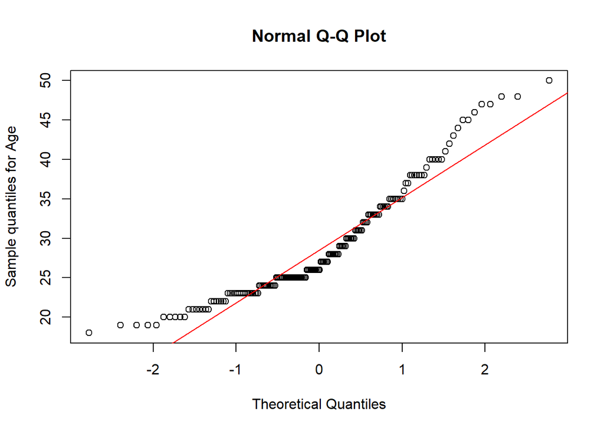

```r
#checking with qqplot
qqnorm(d1$Age, ylab = "Sample quantiles for Age")
qqline(d1$Age, col = 'red')
```

```r
#check with Shapiro-Wilk test
shapiro.test(d1$Age)
```

```
##
##  Shapiro-Wilk normality test
##
## data:  d1$Age
## W = 0.91577, p-value = 1.183e-08
```

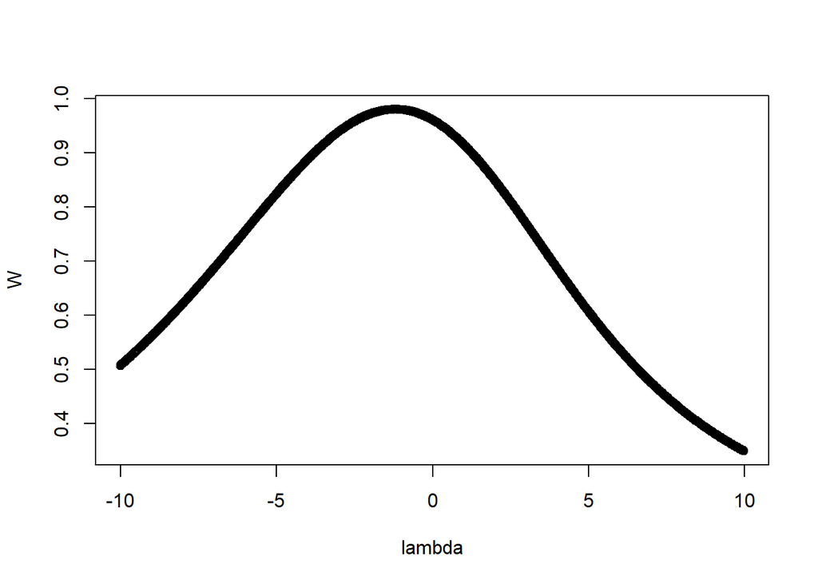

```
##
##     lambda      W Shapiro.p.value
## 351  -1.25 0.9808         0.01379
##
## if (lambda >  0){TRANS = x ^ lambda}
## if (lambda == 0){TRANS = log(x)}
## if (lambda <  0){TRANS = -1 * x ^ lambda}
```

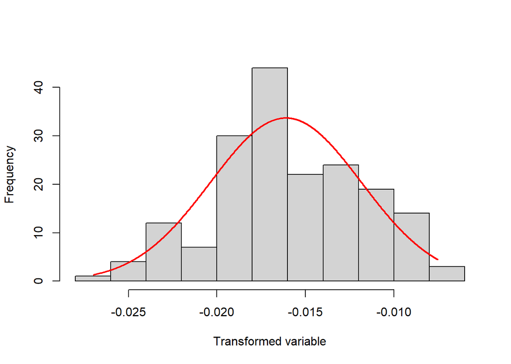

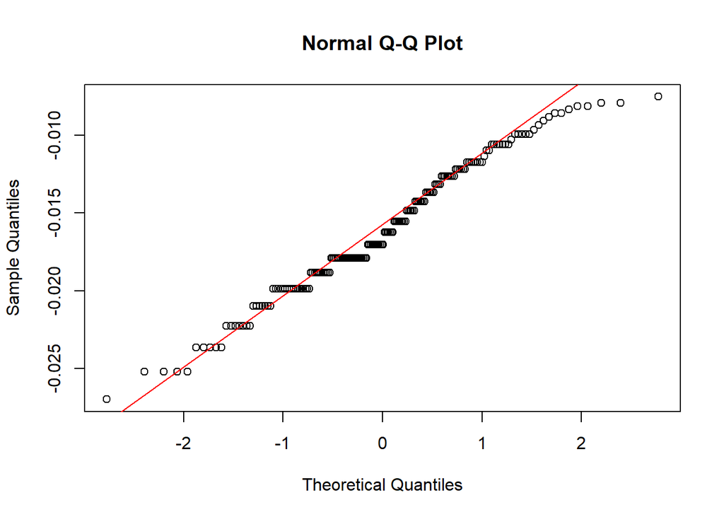

```r
#Tranforming using transformTurkey
d1$AgeNormal = transformTukey(d1$Age, plotit = TRUE)
```

### Computing Predicton Interval Use transformed data to compute mean, sd, upper and lower limit. For 95% PI, use 0.025 or 0.975 in qt(). For 90% PI, use 0.05 or 0.95. After calculation, always transform back values using the formula from transformTurkey() function.

```r
m.age <- mean(d1$AgeNormal)
sd.age <- sd(d1$AgeNormal)
uPI95norm <- m.age - (qt(0.025, df = (nrow(d1) - 1)) * sd.age * sqrt(1+ 1/nrow(d1)))
lPI95norm <- m.age + (qt(0.025, df = (nrow(d1) - 1)) * sd.age * sqrt(1+ 1/nrow(d1)))
cbind(lPI95norm, uPI95norm)
```

```
##        lPI95norm    uPI95norm
## [1,] -0.02453743 -0.007663185
```

```r
#transform back above values
uPI95 <- (-uPI95norm)^(1/-1.25)
lPI95 <- (-lPI95norm)^(1/-1.25)
print(cbind(lPI95, uPI95), digits = 4)
```

```
##      lPI95 uPI95
## [1,] 19.41 49.26
```

### Computing Confidence Interval

Unlike PI, there is no need to check for normality and outliers. For 95% interval, use 0.025 for t or z value. Can use 0.975 but swap +/- sign. (refer to sampling and estimation notes for more)

For computing CI with known Population SD, use z value:

```r
#sample mean +/- z-value * (sd/sqrt(n))
uCI95 <- mean(d1$Age) - qnorm(0.025) * sd(d1$Age)/sqrt(nrow(d1))
lCI95 <- mean(d1$Age) + qnorm(0.025) * sd(d1$Age)/sqrt(nrow(d1))
print(cbind(lCI95, uCI95), digits = 4)
```

```
##      lCI95 uCI95
## [1,] 27.77  29.8
```

For computing CI with unknown Population SD, use t value:

```r
#sample mean +/- t-value * (sd/sqrt(n))
uCI95 <- mean(d1$Age) - qt(0.025, df = nrow(d1) - 1) * sd(d1$Age)/sqrt(nrow(d1))
lCI95 <- mean(d1$Age) + qt(0.025, df = nrow(d1) - 1) * sd(d1$Age)/sqrt(nrow(d1))
print(cbind(lCI95, uCI95), digits = 4)
```

```
##      lCI95 uCI95
## [1,] 27.77 29.81
```

For computing CI for a proportion:

```r
#let prop be proportion of variable mentioned in qn over total
#prop +/- z-value * (sqrt(prop(1 - prop) / n))

dmale <- d1 %>% filter(Gender == 'Male')
pmale <- nrow(dmale)/nrow(d1)
lCIpmale<- pmale + (qnorm(0.025)*sqrt(pmale*(1-pmale)/nrow(d1)))
uCIpmale <- pmale - (qnorm(0.025)*sqrt(pmale*(1-pmale)/nrow(d1)))
print(cbind(lCIpmale, uCIpmale), digits = 4)
```

```
##      lCIpmale uCIpmale
## [1,]   0.5056   0.6499
```

## Hypothesis Testing

Refer to flowchart:

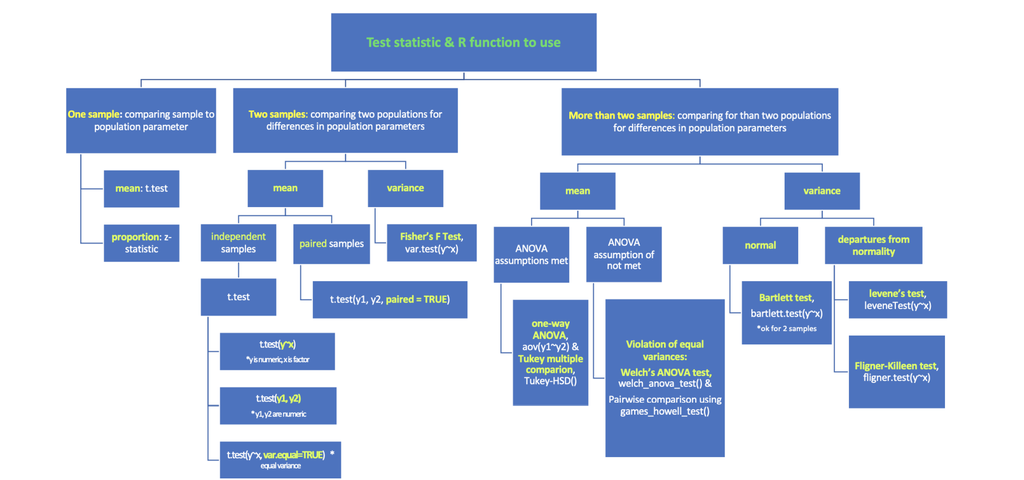

### Two-sample

```r
#t.test(y~x) where y is a numeric and x is a factor
t.test(Income ~ Gender, data = d1)
```

```
##
##  Welch Two Sample t-test
##
## data:  Income by Gender
## t = -2.9146, df = 177.23, p-value = 0.004021
## alternative hypothesis: true difference in means between group Female and group Male is not equal to 0
## 95 percent confidence interval:
##  -11293.312  -2174.392
## sample estimates:
## mean in group Female   mean in group Male
##             49828.91             56562.76
```

```r
#t.test(y1,y2) where both are numeric
```

### More than 2 sample

For comparison of mean use either ANOVA or welch. Check if the variables meet the assumptions of ANOVA - 1. Randomly and independently obtained 2. Normally distributed 3. Have equal variances (use welch if not equal)

```r
#check normality (refer above)
#check equal variance - fligner test

#WELCH TEST
welch.prodIncome <-d1 %>% welch_anova_test(Income ~ Product)
welch.prodIncome
```

```
## # A tibble: 1 x 7
##   .y.        n statistic   DFn   DFd        p method
## * <chr>  <int>     <dbl> <dbl> <dbl>    <dbl> <chr>
## 1 Income   180      43.6     2  85.5 8.64e-14 Welch ANOVA
```

```r
#WELCH TEST - POST-HOC
gh.prodIncome <- games_howell_test(d1, Income ~ Product)
gh.prodIncome
```

```
## # A tibble: 3 x 8
##   .y.    group1 group2 estimate conf.low conf.high    p.adj p.adj.signif
## * <chr>  <chr>  <chr>     <dbl>    <dbl>     <dbl>    <dbl> <chr>
## 1 Income TM195  TM498     2556.   -1022.     6134. 2.12e- 1 ns
## 2 Income TM195  TM798    29024.   21536.    36511. 1.86e-12 ****
## 3 Income TM498  TM798    26468.   18905.    34031. 8.89e-11 ****
```

```r
#ANOVA TEST
aov.prodIncome <- aov(d1$Income ~ d1$Product)
summary(aov.prodIncome)
```

```
##              Df    Sum Sq   Mean Sq F value Pr(>F)
## d1$Product    2 2.449e+10 1.225e+10   89.26 <2e-16 ***
## Residuals   177 2.428e+10 1.372e+08
## ---
## Signif. codes:  0 '***' 0.001 '**' 0.01 '*' 0.05 '.' 0.1 ' ' 1
```

```r
#ANOVA - POST-HOC
TukeyHSD(aov.prodIncome)
```

```
##   Tukey multiple comparisons of means
##     95% family-wise confidence level
##
## Fit: aov(formula = d1$Income ~ d1$Product)
##
## $`d1$Product`
##                  diff       lwr       upr    p adj
## TM498-TM195  2555.625 -2172.321  7283.571 0.409684
## TM798-TM195 29023.550 23662.563 34384.537 0.000000
## TM798-TM498 26467.925 20816.948 32118.902 0.000000
```

## Linear Regression

### Simple LM

Linear regression model: Y = b0 + b1 * X + e When typing out the linear regression model equation make sure to include the error term, e!

```r
summary(lm(recid$durat ~recid$tserved, recid))
```

```
##
## Call:
## lm(formula = recid$durat ~ recid$tserved, data = recid)
##
## Residuals:
##    Min     1Q Median     3Q    Max
## -57.71 -26.79  14.28  19.90  73.24
##
## Coefficients:
##               Estimate Std. Error t value Pr(>|t|)
## (Intercept)   60.23062    0.95526  63.052  < 2e-16 ***
## recid$tserved -0.25327    0.03362  -7.533 8.74e-14 ***
## ---
## Signif. codes:  0 '***' 0.001 '**' 0.01 '*' 0.05 '.' 0.1 ' ' 1
##
## Residual standard error: 26.79 on 1443 degrees of freedom
## Multiple R-squared:  0.03783,    Adjusted R-squared:  0.03717
## F-statistic: 56.74 on 1 and 1443 DF,  p-value: 8.737e-14
```

Example of Intepretation of variable: The coef before tserved is (-0.25327) and it means that “one more month increase in prison time (penalty) decreases the recidivism duration by 0.25327 month, **on average**”. It is statistically different from zero from the large t-value and extremely small p-value.

Template: The coef before x is (x-value) and it means that “one unit of increase in x decrease/increase the y by x-value, **on average**’’. It is statistically different from zero from the large t-value and extremely small p-value. OR Small t-value and large p-value imply that we fail to reject the null hypothesis that slope coef beta for x is zero.

### Multivariate LM

```r
fit_d = lm(durat ~ tserved + drugs + alcohol + priors + workprg, data = recid)
summary(fit_d)
```

```
##
## Call:
## lm(formula = durat ~ tserved + drugs + alcohol + priors + workprg,
##     data = recid)
##
## Residuals:
##    Min     1Q Median     3Q    Max
## -61.13 -26.17  13.81  18.93  75.50
##
## Coefficients:
##             Estimate Std. Error t value Pr(>|t|)
## (Intercept) 62.24434    1.24993  49.798  < 2e-16 ***
## tserved     -0.25630    0.03474  -7.378  2.7e-13 ***
## drugs       -2.36192    1.63400  -1.445 0.148539
## alcohol     -5.59695    1.75927  -3.181 0.001497 **
## priors      -0.90386    0.25443  -3.553 0.000394 ***
## workprg      2.32777    1.43840   1.618 0.105816
## ---
## Signif. codes:  0 '***' 0.001 '**' 0.01 '*' 0.05 '.' 0.1 ' ' 1
##
## Residual standard error: 26.52 on 1439 degrees of freedom
## Multiple R-squared:  0.05958,    Adjusted R-squared:  0.05631
## F-statistic: 18.23 on 5 and 1439 DF,  p-value: < 2.2e-16
```

For multivariate linear regression, template is similar. Template:

The coef before x is (x-value) and it means that “one unit of increase in x decrease/increase the y by x-value, **on average, holding all other independent variables constant**”. It is statistically different from zero from the large t-value and extremely small p-value. OR Small t-value and large p-value imply that we fail to reject the null hypothesis that slope coef beta for X is zero.

### Checking assumptions of LM

Assumptions of linear regression mostly concerns the error term , e.

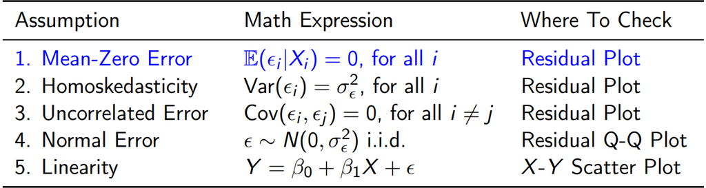

X-Y Scatter plot to check linearity:

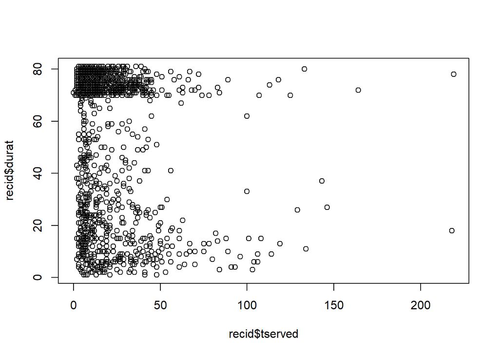

```r
#plot(x, y, main = "name here", xlab ="", ylab = "")
plot(recid$tserved, recid$durat)
```

Residual and Residual QQ plots to check other assumptions:

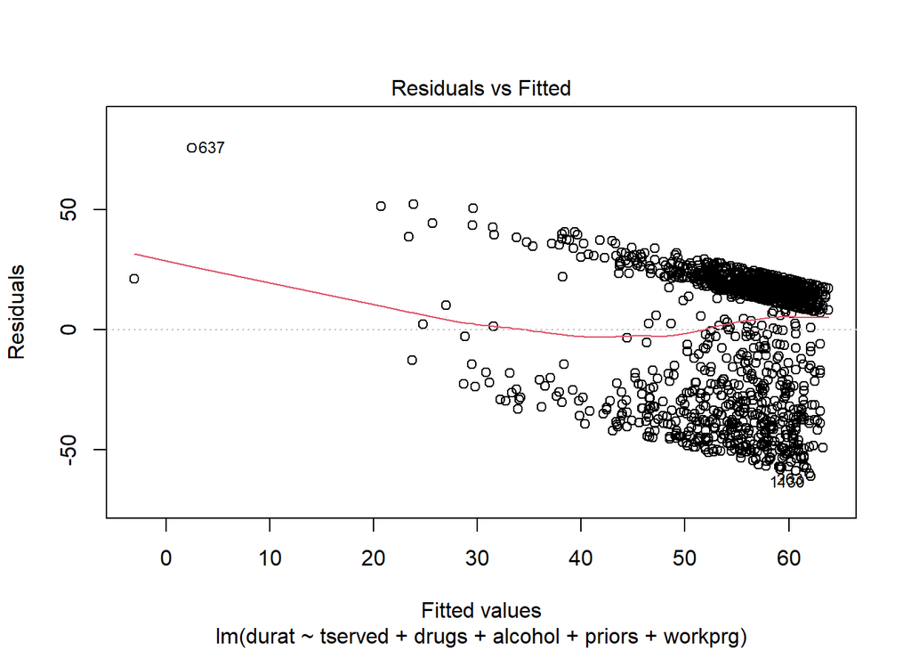

```r
# residual plot (resid vs. fitted value)
plot(fit_d, 1)
```

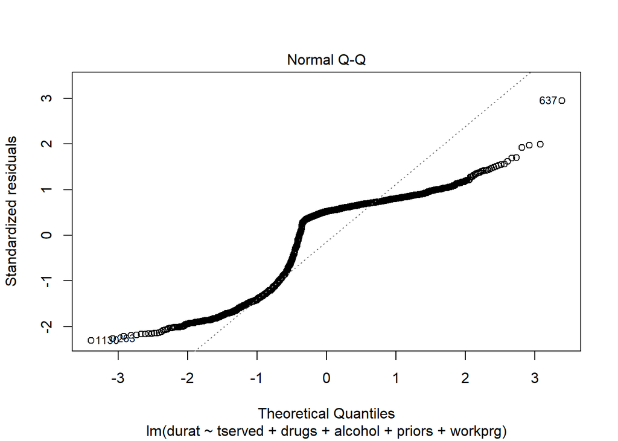

```r
# residual Q-Q plot
plot(fit_d, 2)
```

Taken from model answer in Tutorial 6: From the residual plot, we can see a significant decreasing pattern of residuals when fitted value gets larger. This implies not only autocorrelation but a strong correlation between the residuals and fitted value y^ or implicitly some of independent variables X’s as well. The latter is more sever, violating assumption of mean-zero error. The OLS estimator is not valid, in terms of (1) biased estimate and (2) wrong standard error and invalid inference.

Residual Q-Q plot also shows that the plot is tilted away from 45 degree line, violating the assumption that the error follows a normal distribution. Consistent with what we found from residual plot.

Note: The failure of mean-zero error is likely due to missing variables, i.e. some key variables that are unobserved (thus left in the error term) to us but correlate with independent variables X’s. More inspection thus is needed to draw a valid conclusion.

### Prediction

```r
#type in new subject as a data frame with all relevant variables
fit_f = lm(follow ~ rules + age + tserved + married,  data = recid)
newoffender = data.frame(rules = 0, age = 32*12, tserved = 3*12+7, married = 1)
predict(fit_f, newdata = newoffender)
```

```
##        1
## 74.52686
```

## Logistic Regression and Time Series

### Genaralized LM

glm() is used when the Y variable is a binary/categorical (instead of numeric). Use glm() instead of lm() and with ‘family = binomial’.

```r
logit_s = glm(super ~ rules + age + tserved + married + black, family = binomial, data = recid)
summary(logit_s)
```

```
##
## Call:
## glm(formula = super ~ rules + age + tserved + married + black,
##     family = binomial, data = recid)
##
## Deviance Residuals:
##     Min       1Q   Median       3Q      Max
## -2.9171  -1.2826   0.7302   0.8673   1.9883
##
## Coefficients:
##               Estimate Std. Error z value Pr(>|z|)
## (Intercept)  1.0144454  0.1965122   5.162 2.44e-07 ***
## rules       -0.2440268  0.0359240  -6.793 1.10e-11 ***
## age         -0.0018470  0.0004914  -3.759 0.000171 ***
## tserved      0.0319665  0.0048895   6.538 6.25e-11 ***
## married      0.5115352  0.1458073   3.508 0.000451 ***
## black        0.1132077  0.1189016   0.952 0.341040
## ---
## Signif. codes:  0 '***' 0.001 '**' 0.01 '*' 0.05 '.' 0.1 ' ' 1
##
## (Dispersion parameter for binomial family taken to be 1)
##
##     Null deviance: 1779.6  on 1444  degrees of freedom
## Residual deviance: 1687.6  on 1439  degrees of freedom
## AIC: 1699.6
##
## Number of Fisher Scoring iterations: 4
```

### Prediction

To predict probabiity of binary X being a success, add type = ‘response’ into predict() function.

```r
#type in new subject as a data frame with all relevant variables
newclient = data.frame(rules = 0, age = 46*12, tserved = 3*12+7, married = 1, black = 0)
predict(logit_s, newdata = newclient, type = 'response')
```

```
##         1
## 0.8677237
```

### Plot Moving average

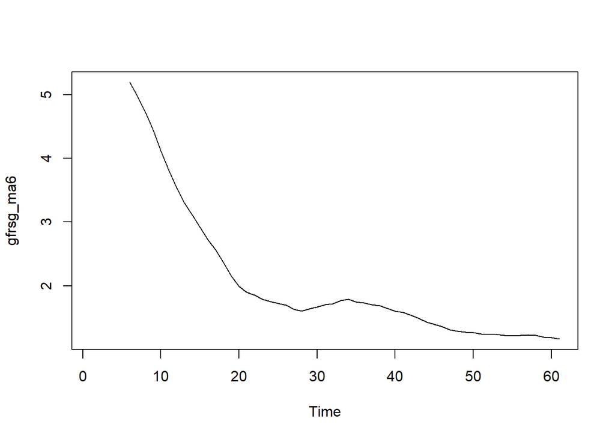

```r
# n = is the window length
gfrsg_ma6 = TTR::SMA(sgfertil$Total.Fertility.Rate..Per.Female., n = 6)
ts.plot(gfrsg_ma6)
```

Usage of HoltWinters() depends on trend, seasonality and parameters of time series.

```r
gfrsg_hw = HoltWinters(gfrsg, gamma = FALSE)
gfrsg_hw
```

```
## Holt-Winters exponential smoothing with trend and without seasonal component.
##
## Call:
## HoltWinters(x = gfrsg, gamma = FALSE)
##
## Smoothing parameters:
##  alpha: 1
##  beta : 0.2165719
##  gamma: FALSE
##
## Coefficients:
##          [,1]
## a  1.10000000
## b -0.01932966
```

```r
#prediction w HoltWinter
gfrsg_hwp= predict(gfrsg_hw, n.ahead = 4)
```

## Data Mining

### Linear Hypothesis Test

```r
lm_1 = lm(stndfnl ~ attend + termGPA + priGPA + ACT + hwrte + frosh + soph, data = attend)
linearHypothesis(lm_1, c("termGPA = 0", "priGPA = 0", "ACT = 0"))
```

```
## Linear hypothesis test
##
## Hypothesis:
## termGPA = 0
## priGPA = 0
## ACT = 0
##
## Model 1: restricted model
## Model 2: stndfnl ~ attend + termGPA + priGPA + ACT + hwrte + frosh + soph
##
##   Res.Df    RSS Df Sum of Sq      F    Pr(>F)
## 1    669 638.97
## 2    666 439.46  3    199.51 100.79 < 2.2e-16 ***
## ---
## Signif. codes:  0 '***' 0.001 '**' 0.01 '*' 0.05 '.' 0.1 ' ' 1
```

```r
#automated backward model
step(lm_1, direction = 'backward')
```

```
## Start:  AIC=-272.26
## stndfnl ~ attend + termGPA + priGPA + ACT + hwrte + frosh + soph
##
##           Df Sum of Sq    RSS     AIC
## - priGPA   1     0.007 439.47 -274.25
## - frosh    1     1.091 440.55 -272.59
## - hwrte    1     1.179 440.64 -272.45
## <none>                 439.46 -272.26
## - attend   1     1.894 441.36 -271.36
## - soph     1     2.867 442.33 -269.88
## - ACT      1    19.449 458.91 -245.07
## - termGPA  1    83.717 523.18 -156.73
##
## Step:  AIC=-274.25
## stndfnl ~ attend + termGPA + ACT + hwrte + frosh + soph
##
##           Df Sum of Sq    RSS     AIC
## - frosh    1     1.104 440.57 -274.56
## - hwrte    1     1.173 440.64 -274.45
## <none>                 439.47 -274.25
## - attend   1     2.083 441.55 -273.06
## - soph     1     2.879 442.35 -271.85
## - ACT      1    20.973 460.44 -244.82
## - termGPA  1   104.720 544.19 -132.19
##
## Step:  AIC=-274.55
## stndfnl ~ attend + termGPA + ACT + hwrte + soph
##
##           Df Sum of Sq    RSS     AIC
## - hwrte    1     1.058 441.63 -274.94
## <none>                 440.57 -274.56
## - soph     1     1.775 442.35 -273.85
## - attend   1     2.259 442.83 -273.11
## - ACT      1    21.919 462.49 -243.83
## - termGPA  1   105.669 546.24 -131.65
##
## Step:  AIC=-274.94
## stndfnl ~ attend + termGPA + ACT + soph
##
##           Df Sum of Sq    RSS     AIC
## <none>                 441.63 -274.94
## - soph     1     1.997 443.63 -273.90
## - attend   1     4.704 446.33 -269.80
## - ACT      1    23.636 465.27 -241.80
## - termGPA  1   108.245 549.87 -129.19
```

```
##
## Call:
## lm(formula = stndfnl ~ attend + termGPA + ACT + soph, data = attend)
##
## Coefficients:
## (Intercept)       attend      termGPA          ACT         soph
##    -2.61479     -0.02003      0.72305      0.05984     -0.11153
```

### Principle Component Analysis

```r
attend_pca <- prcomp(attendX, center = TRUE, scale = TRUE)
summary(attend_pca)
```

```
## Importance of components:
##                           PC1    PC2     PC3     PC4     PC5
## Standard deviation     1.6006 1.1491 0.69665 0.57731 0.54701
## Proportion of Variance 0.5124 0.2641 0.09707 0.06666 0.05984
## Cumulative Proportion  0.5124 0.7764 0.87350 0.94016 1.00000
```

```r
attend$pc1 <- attend_pca$x[,"PC1"]
attend$pc2 <- attend_pca$x[,"PC2"]
attend$pc3 <- attend_pca$x[,"PC3"]
attend$pc4 <- attend_pca$x[,"PC4"]

attend_pca$rotation[,1:4]
```

```
##                PC1        PC2         PC3         PC4
## attend  -0.4894187  0.3655846  0.13026292 -0.75045972
## termGPA -0.5442744 -0.1439334  0.08088831  0.48919402
## priGPA  -0.4831642 -0.3391988  0.54319195  0.07361334
## ACT     -0.1412554 -0.7684402 -0.50934291 -0.35806303
## hwrte   -0.4591666  0.3742659 -0.64961600  0.25272784
```

### Classification (Confusion) Matrix

Refer to Tutorial 8

```r
#Base R table() OR
#confusionMatrix()
```

## Linear Optimization

### Solving linear problem

```r
#All variables based on the table
obj.fn <- c(6000, 15000, 23000)
const.mat <- matrix(c(0.5, 2, 4, 2, 1.5, 1), ncol = 3, byrow = TRUE)
const.dir <- c("<=", "<=")
const.rhs <- c(72, 48)

#lp() to find output - change to min when finding minimum output
lp.solution <- lp("max", obj.fn, const.mat, const.dir, const.rhs, compute.sens = TRUE)
lp.solution$solution
```

```
## [1]  0 30  3
```

```r
#Maximum output
lp.solution
```

```
## Success: the objective function is 519000
```

### What ifs

```r
# display the lowerbound that current solution remains the same
print(lp.solution$sens.coef.from)
```

```
## [1] -1.000000e+30  1.316667e+04  1.000000e+04
```

```r
print(lp.solution$sens.coef.to)
```

```
## [1]  9437.50 34500.00 27230.77
```

```r
print(lp.solution$duals)
```

```
## [1]  4875.0  3500.0 -3437.5     0.0     0.0
```